# CHAPTER C3

# 曲げにおける降伏および極限強度

## C3.1 導入

飛行体の構造物においては、曲げ単独、あるいは軸荷重やねじり荷重が組み合わさった荷重を受ける部材が極めて一般的である。構造部材に対する制限設計荷重は永久変形を伴わずに支持されなければならず、極限設計荷重は破断や崩壊を伴わずに支持されなければならない。よく知られた曲げ応力の式 $f_b = Mc/I$ は、応力とひずみが線形変化することを前提としており、換言すれば、この式は比例限度応力以下、あるいは一般に弾性範囲内の応力に対して有効である。曲げを受ける部材の破壊は、局所的な欠陥がない限り、弾性範囲の応力では発生せず、非弾性範囲の応力で発生する。支持すべき極限設計荷重と比較するためには部材の極限強度が必要となるため、曲げを受ける部材の極限強度および降伏強度を正確に決定できる理論または手順が必要である。

## C3.2 部材の曲げ強度を求めるための基本アプローチ

問題は、応力が応力の非弾性範囲に入る場合に、梁断面の内部抵抗モーメントを決定することである。この応力は、材料の極限引張応力または極限圧縮応力として扱うこともできるし、非弾性範囲における特定の応力または変形に制限することもできる。真の内部抵抗モーメントを得るためには、垂直引張応力および垂直圧縮応力が断面全体にわたってどのように変化するかを知る必要がある。材料の応力-ひずみ曲線は、真の応力状態を得るための情報源となる。材料が引張側と圧縮側の非弾性領域で異なる形状を持つ場合、中立軸は図心軸と一致しなくなり、解析方法がやや複雑になる。真の内部抵抗モーメントを決定するための解析手順は、具体的な計算例を用いて説明するのが最も分かりやすい。

## C3.3 丸丸棒の曲げ強度

Fig. C3.1a はアルミ合金製の丸棒の断面を示している。 $0.010\text{ in./in.}$ の単位ひずみまでの応力-ひずみ曲線を Fig. C3.2 に示す。非弾性領域における曲線の形状は、引張と圧縮で同じではないことに注意されたい。この計算例では、梁断面の圧縮側の最外縁における単位ひずみを $0.010$ に制限したときの内部抵抗モーメントを求める。純粋曲げ状態においては、弾性応力状態および非弾性応力状態のいずれにおいても、曲げの前後で平面断面は平面を維持する。

中立軸は Fig. C3.1b に示すように、図心軸から $0.0375\text{ インチ}$ 上方に位置していると仮定する。最大単位ひずみを $0.010$ と仮定したため、Fig. C3.1b のひずみ図を描くことができる。次に、Fig. C3.1a の断面を20本の細い水平な帯板に分割する。Fig. C3.1b のひずみ曲線を用いることで、各帯板の中心における単位ひずみを求めることができる。

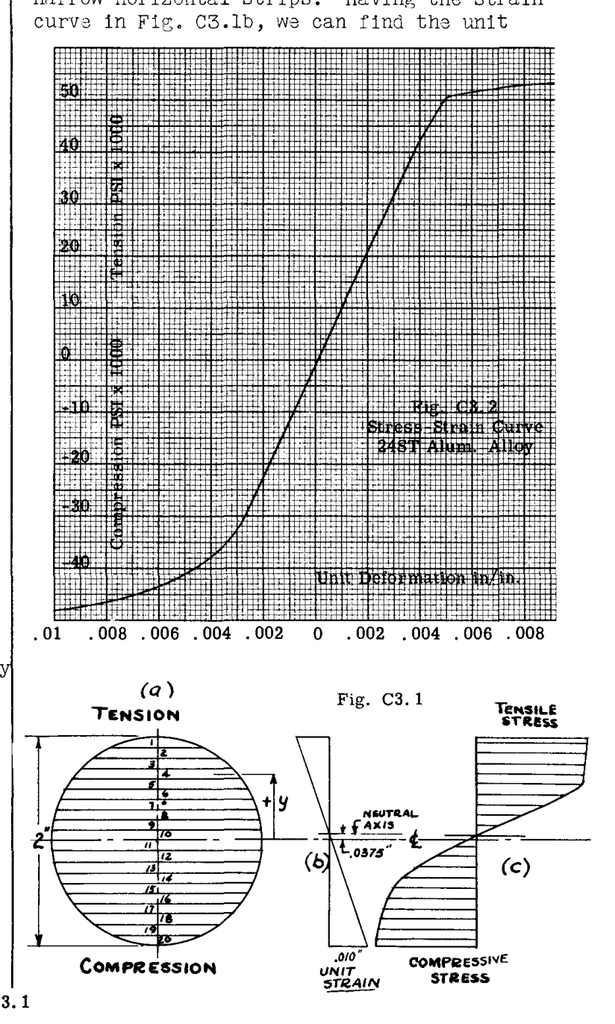

Fig. C3.1

各帯板のひずみが分かれば、Fig. C3.2 の応力-ひずみ曲線を用いて、そこに作用している応力を求めることができる。各帯板における全荷重は、応力に帯板の面積を乗じたものに等しくなる。内部抵抗モーメントは、各帯板における荷重に、帯板から中立軸までの距離を乗じたものの総和に等しくなる。

TABLE C3.1 に詳細な計算を示す。中立軸が正しい位置に選択されていれば、断面上の全引張力と全圧縮力は等しくなければならないため、表の第 (6) 列の数値の合計はゼロになるはずである。第 (6) 列の合計における $740\text{ ポンド}$ というわずかな不一致は、中立軸の位置や全内部抵抗モーメントを大きく変えるほどのものではない。ひずみが前述のように $0.010$ に制限されている場合、第 (7) 列より全内部抵抗モーメントは $56735\text{ in. lbs.}$ となる。Fig. C3.2 から、このひずみにおける応力は $49000\text{ psi}$ である。よく知られた梁の公式 $M = fI/c$ にこの応力を適用すると、 $M = 49000 \times 0.785 = 38450$ となり、これは真の値である $56735$ よりもはるかに小さい。

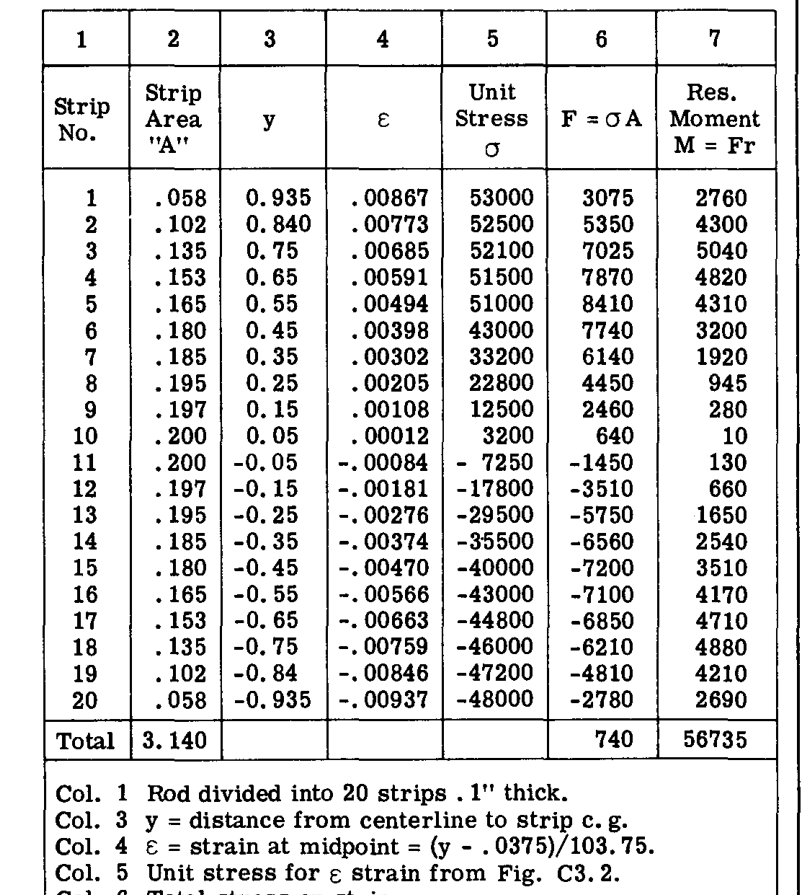

TABLE C3.1

与えられた曲げモーメントによる曲げ応力を求めるため、また梁断面の真の内部抵抗モーメントを決定するために梁の公式を使用することが望ましいため、構造設計エンジニアは、純粋曲げにおける破断係数応力と呼ばれる、仮想的な破壊曲げ応力 $F_b$ を使用する。そうすれば、与えられた梁断面および材料で発生させることができる極限曲げモーメントは $M = F_b I/c$ となる。破断係数 $F_b$ を求めるための設計曲線は、この章の後半に示されている。

飛行体用の材料は多種多様であり、構造部材に使用される形状も様々であるため、TABLE C3.1 に示すような基本的な解析アプローチは非常に時間がかかる。設計エンジニアは常に、十分な精度を提供する簡略化された方法を求めている。そこで Cozzone (文献 1) は、降伏モーメントまたは破断曲げ応力 $F_b$ を求めるための簡略化された手順を開発した。この方法は航空宇宙産業の構造設計において広く使用されている。

## C3.4 Cozzone の簡略化された手順

最も単純な形式における Cozzone の方法は、対称な矩形梁断面を仮定し、引張と圧縮の両方で同じ形状の応力-ひずみ曲線を持つと仮定する。Fig. C3.3 は、破壊が発生したときの梁断面にわたる真の曲げ応力変化を示している。Cozzone は、この真の曲線を Fig. C3.4 に示すような台形応力変化に置き換える。応力 $f_o$ は、中立軸またはひずみがゼロの位置に存在すると仮定される仮想的な応力である。

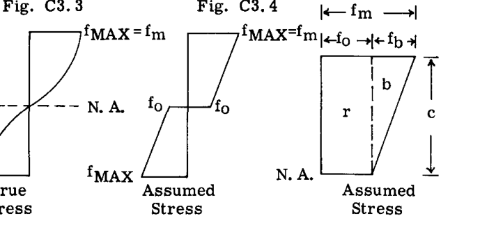

Fig. C3.3, Fig. C3.4

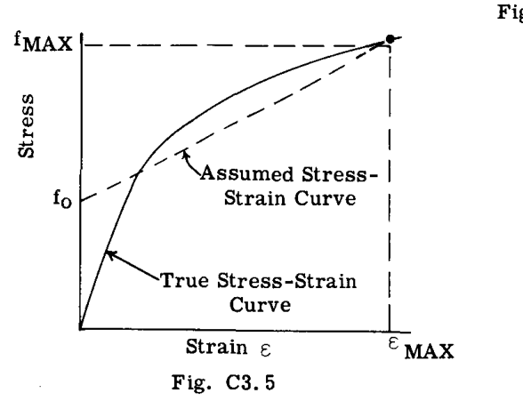

Fig. C3.5, Fig. C3.6

$f_o$ の値は、真の応力状態による内部モーメントが、Fig. C3.5 に示す想定応力-ひずみ曲線から得られる台形応力状態のモーメントと等しくなければならないという要求から決定される。Fig. C3.6 は、台形応力パターンを拡大して描き、対称な梁断面の半分だけを示したものである。台形応力パターンは、図に示すように矩形部分 (r) と三角形部分 (b) に分割されている。

ここで、 $M_b$ = 全内部抵抗モーメント $m_r$ = 部分 (r) によって生じる内部モーメント $m_b$ = 部分 (b) によって生じる内部モーメント とする。

したがって、

$$M_b = m_r + m_b$$

$f_b$ はゼロから $f_b$ まで線形に変化するため、応力は弾性的であり、したがって梁の公式が成立する。すなわち、

断面全体に対して $m_b = f_b I/c$ である。部分 (r) における応力変化は一定、すなわち矩形であるため、

$$m_r = f_o \int y dA$$

であり、 $\int y dA = Q$ とおくと、

断面全体に対して $m_r = 2 f_o Q$ となる。

しかし、Fig. C3.6 より $f_b = f_m - f_o$ である。

したがって、 $M_b = (f_m - f_o) \frac{I}{c} + 2 f_o Q$ 、すなわち

$$\frac{M_b c}{I} = f_m + f_o \left( \frac{2Q}{I/c} - 1 \right) \quad
\text{--- (1)}$$

ここで、

$$k = \frac{2Q}{I/c} \quad \text{--- (2)}$$

とおく。 $k$ は梁断面の形状係数である。

$F_b = M_{bc}/I$ とおくと、式 (1) から以下のようになる。

$$F_b = f_m + f_o(k - 1) \quad \text{--- (3)}$$

$F_b$ は、特定の最大応力レベルにおける仮想的な $Mc/I$ 応力、または特定の断面に対する破断係数である。

$k$ の値は $1$ から $2.0$ の間で変化する。算出された $k$ の値が $2$ より大きい場合は、 $2.0$ を使用する。Fig. C3.7 は、いくつかの代表的な形状における形状係数 $k$ の値を示している。Fig. C3.8 は、3つの一般的な梁断面について $k$ 係数を迅速に決定するための曲線を示している。

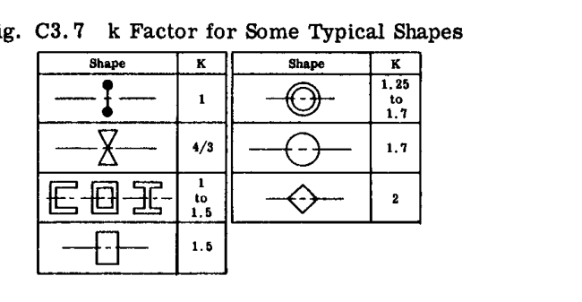

Fig. C3.7

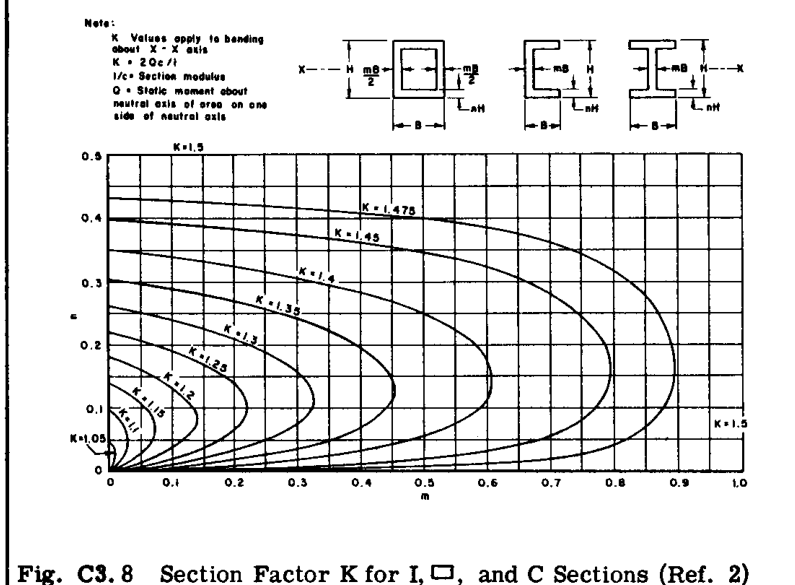

Fig. C3.8

## C3.5 破断係数 ( $F_b$ ) を求めるための設計曲線

破断係数 $F_b$ は降伏係数であってもよく、その場合、式 (3) における $f_m$ の値は材料の降伏応力に等しくなる。また、極限破断係数であってもよく、その場合、式 (3) における $f_m$ の値は材料の極限強度に等しくなる。破断係数は、局所座屈または過度の変形により、材料の降伏応力と極限応力の間の応力に制限されることがある。式 (3) で $f_m$ にどのような値を使用するかにかかわらず、 $F_b$ の値を決定する前に、対応する $f_o$ の値を知る必要がある。Fig. C3.9 から Fig. C3.23 は、さまざまな材料のひずみ曲線と対応する $f_o$ 曲線を示している。これら2つの曲線を使用することで、検討対象の特定の梁断面における形状係数 $k$ が既知であれば、 $F_b$ を決定することができる。 $f_o$ の値を導出するにあたり、以下の仮定がなされている。

1. 応力-ひずみ曲線は引張と圧縮で同じであると仮定する。
2. 中立軸は図心軸と一致すると仮定する。
3. 曲げの間、平面断面は平面を維持する。
4. 断面は局所不安定性またはねじり不安定性を生じない。
5. 梁-柱、曲率、およびせん断遅れの影響は無視できるものとする。

## C3.6 方法の一般的な精度

1. モーメントベクトルが主軸に平行な純粋曲げを受ける矩形断面に対しては、この方法は厳密である。
2. モーメントベクトルが主軸に平行な純粋曲げを受ける二重対称断面に対しては、精度は 5% 以内であるはずである。
3. 一軸対称断面は、実質的に厳密なものから、明らかに非安全側（モーメントベクトルが対称軸に垂直な場合）まで変化する。
4. 曲げと軸荷重を同時に受ける断面に対しては、結果は実質的に厳密なものから安全側まで変化する。
5. 軸荷重を伴う、あるいは伴わない非対称曲げに対しては、結果は実質的に厳密なものから安全側まで変化する。

## C3.7 曲げ強度を求める例題

### 例題 1

幅 $0.25\text{ インチ}$ 、深さ $1.5\text{ インチ}$ の矩形梁断面がある。7075-T6押出アルミ合金製であるとき、この断面が発生させる降伏曲げモーメントおよび極限曲げモーメントはいくらか。

解法： 曲げ応力の係数は式 (3) によって与えられる。

$$F_b = f_m + f_o(k - 1) \quad \text{--- (3)}$$

$$k = \frac{2Q}{I/c} = \frac{2 \times 0.75 \times .25 \times
.375}{\left(\frac{1}{12}\right) .25 \times 1.5^3(1/.75)} =
\frac{.1408}{.0938}$$

$$k = 1.50$$

$k$ の値は Fig. C3.7 からも求めることができる。

材料は 7075-T6アルミ合金である。Fig. C3.17 より、 $F_{tu} = 75000$ 、 $F_{ty} = 65000$ である。

降伏曲げ強度を求めるには、式 (3) における $f_m$ の値、すなわち最外縁繊維で許容される最大応力は、材料の降伏応力である $65000$ である。 $f_o$ を求めるために、Fig. C3.17 に進み、応力-ひずみ曲線上で $65000$ の応力に対応する点を見つける。この点から垂直下方に投影して $f_o$ 曲線と交差させる。この交点をチャートの端にある応力目盛りに投影して $f_o$ の値を得る。このチャート操作から得られる $f_o$ の値は $f_o = 29000$ である。そこで式 (3) より、

$$F_{byield} = 65000 + 29000 (1.5 - 1) = 79500\text{ psi}$$

したがって、降伏曲げモーメント $M_{yp} = F_b I/c$

よって、

$$M_{yp} = 79500 \times .0938 = 7460\text{ in. lb.}$$

極限抵抗曲げを求めるためには、式 (3) における $f_m$ の値として $F_{tu}$ である $75000$ を使用する。再び Fig. C3.17 に進み、応力-ひずみ曲線上の応力 $75000$ の点から $f_o$ 曲線まで垂直に下ると、 $f_o = 70500$ が得られる。

したがって、

$$F_{b(ult)} = 75000 + 70500(1.5-1) = 110250\text{ psi}$$

したがって、

$$M_{ult} = F_b I/c = 110250 \times .0938 = 10370\text{ in. lb.}$$

最外縁繊維におけるひずみを $0.03\text{ in./in.}$ に制限したいと仮定する。この制限下で発生する曲げモーメントはいくらになるか。

Fig. C3.17 より、単位ひずみ $0.03$ に対する応力-ひずみ曲線上の対応する応力は $74700$ であり、 $f_o$ 応力は $61200$ である。

したがって、

$$F_b = 74700 + 61200 (1.5-1) = 105300$$

したがって、

$$M = F_b I/c = 105300 \times .0938 = 9900\text{ in. lb.}$$

### 例題 2

Fig. (a) に示す対称I形梁断面が、極限設計純粋曲げモーメント $M = 14000\text{ in. lb.}$ を受けている。梁がマグネシウム鍛造材 AZ61A ( $F_{tu} = 38000$ 、 $F_{ty} = 22000$ ) で作られている場合、安全余裕（margin of safety）はいくらか。

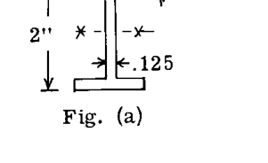

Fig. (a)

$$I_x = \frac{1}{12} \times 1.375 \times 2^3 - \frac{1}{12} \times 1.25
\times 1.75^3 = .916 - .558 = .358$$

$$I_x/c = .358/1 = 0.358$$

$$Q = 1.375 \times .125 \times .9375 + .875 \times .125 \times .4375 =
0.209$$

$$k = \frac{2Q}{I_x/c} = \frac{2 \times .209}{0.358} = 1.17$$

$k$ の値は、Fig. C3.8 から $m = .125/1.375 = .091$ および $n = .125/2.00 = .062$ を使用して求めることもできた。

Fig. C3.19 より、 $f_m = F_{tu} = 38000$ に対して $f_o$ 曲線へ垂直に下行投影すると、 $f_o = 23700$ が得られる。これを式 (3) に代入すると、

$$\text{安全余裕 (Margin of Safety)} = \frac{M_{ult}}{M} - 1 =
\frac{15000}{14000} - 1 = .07$$

完全な曲げ強度が発揮されたときに、中立軸から $0.5\text{ インチ}$ の点における応力強度を求めたいとする。Fig. C3.19 より、応力が $38000$ のときの単位ひずみは $0.035$ である。曲げの後も平面断面は平面を維持するため、中立軸から $.50\text{ インチ}$ の点における単位ひずみは $(.5/1) (.035) = .0175$ となる。Fig. C3.19 より、このひずみにおける応力は $f = 31000\text{ psi}$ である。たわみ公式で用いられるような応力の線形変化を仮定すると、最大応力の半分、すなわち $38000/2 = 19000\text{ psi}$ となり、真の応力である $31000$ と比較して過小評価となる。

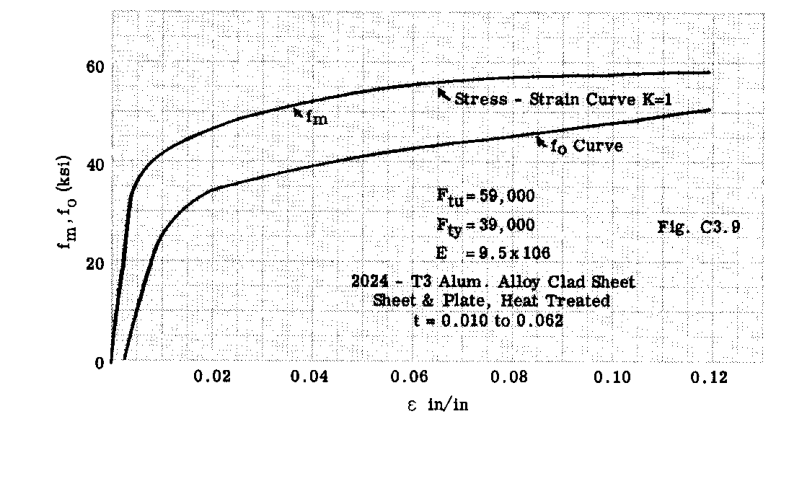

Fig. C3.9

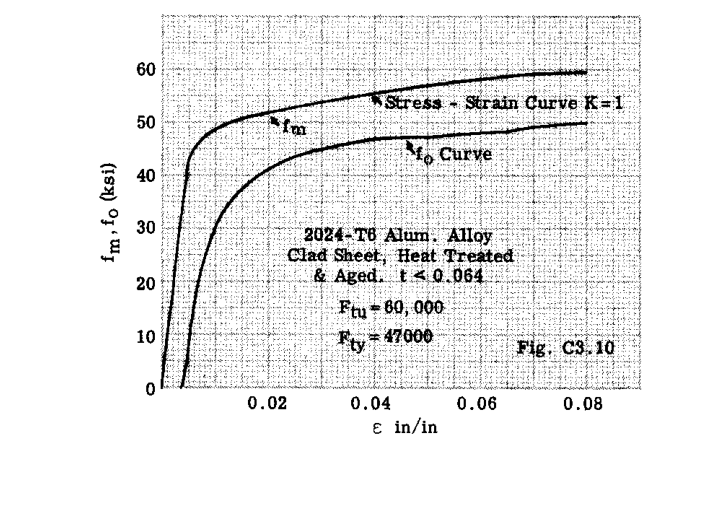

Fig. C3.10

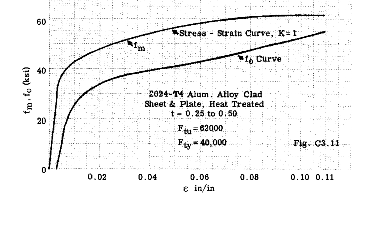

Fig. C3.11

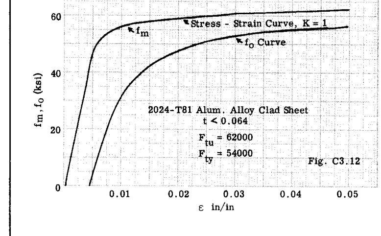

Fig. C3.12

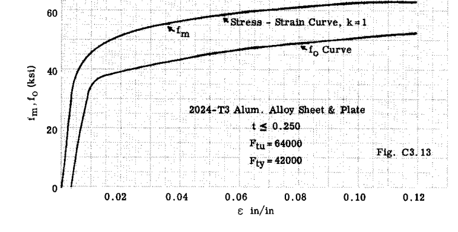

Fig. C3.13

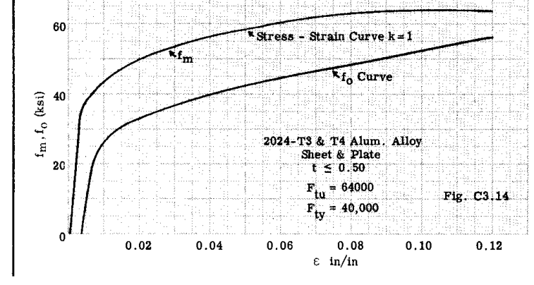

Fig. C3.14

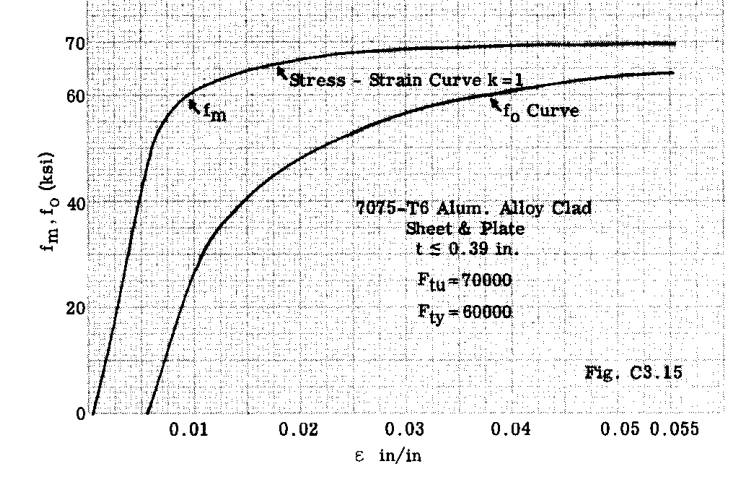

Fig. C3.15

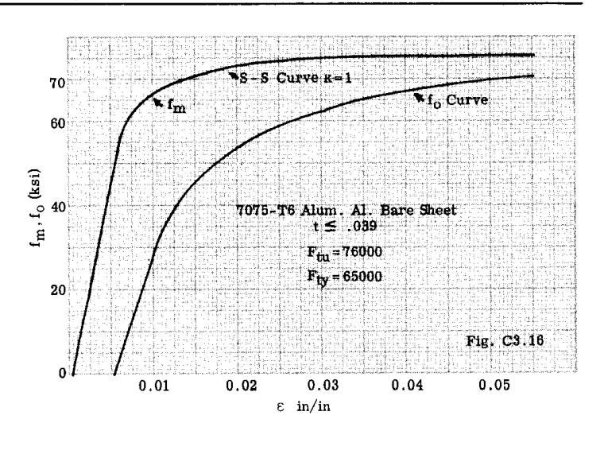

Fig. C3.16

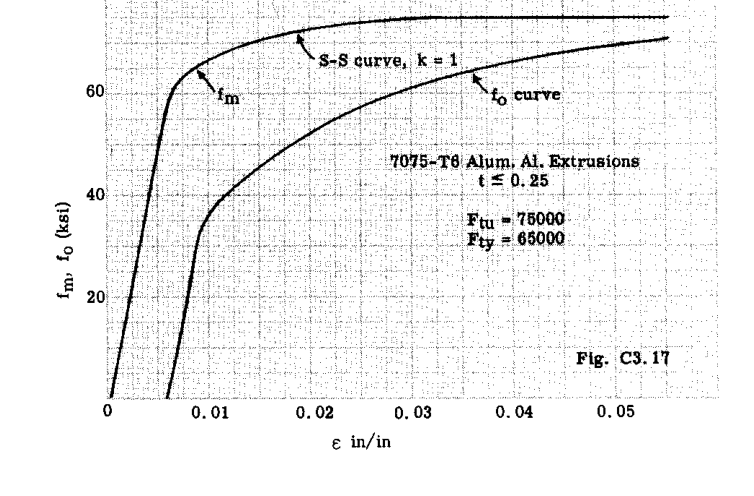

Fig. C3.17

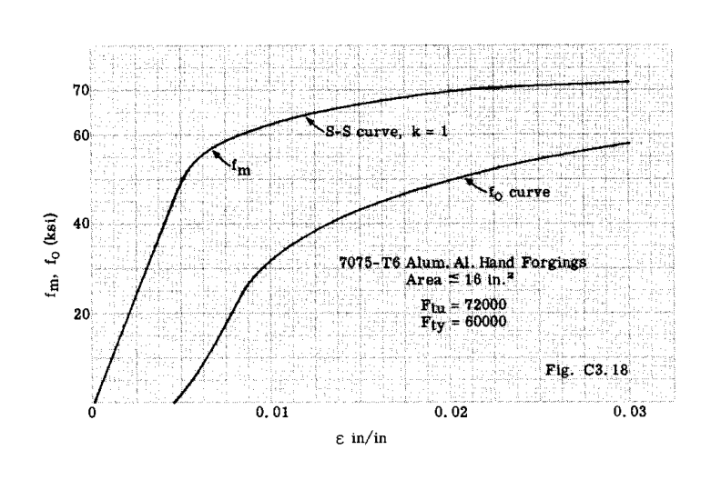

Fig. C3.18

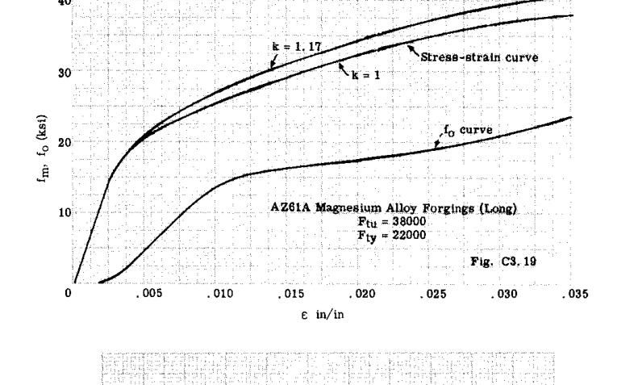

Fig. C3.19

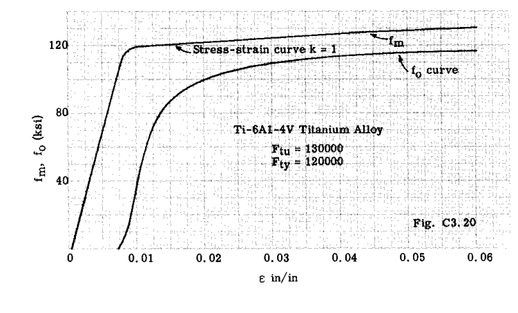

Fig. C3.20

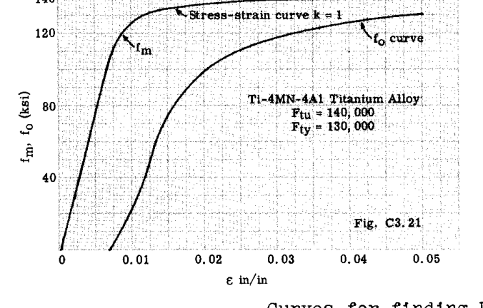

Fig. C3.21

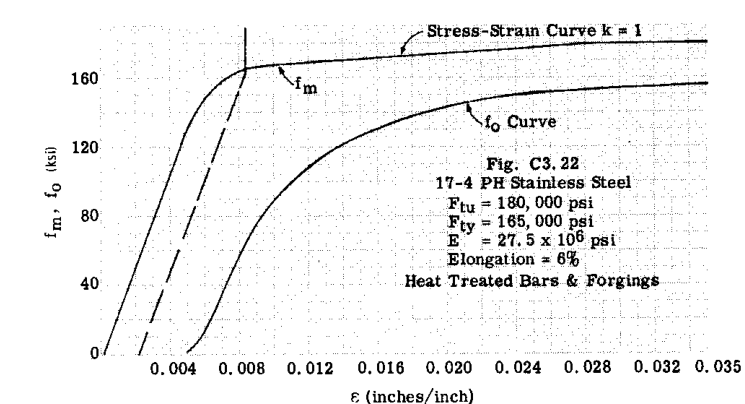

Fig. C3.22

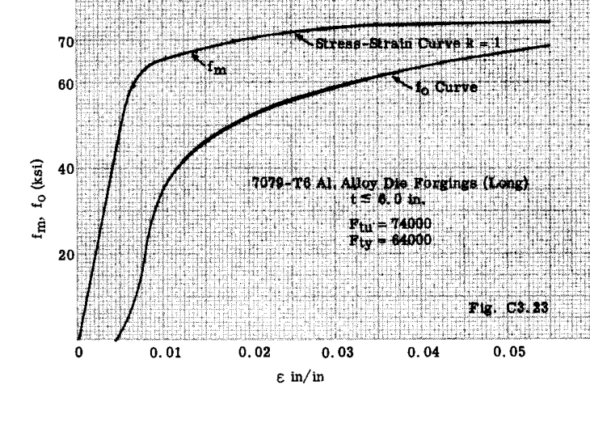

Fig. C3.23

### 例題 3 非対称断面

Fig. (b) は、垂直軸に対して対称なT形梁断面を示している。材料が 17-4 PH ステンレス鋼である場合、下部が引張フランジであると仮定すると、どのような極限曲げモーメントが発生するか。

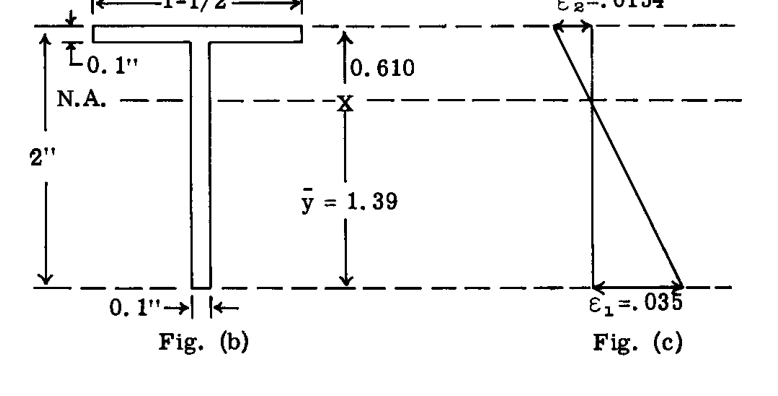

Fig. (b), Fig. (c)

まず中立軸を決定する。

$$\bar{y} = \frac{\sum A y}{\sum A} = \frac{2 \times .1 \times 1 + 1.4
\times .1 \times 1.95}{2 \times .1 + 1.4 \times .1} = 1.39$$

Fig. (c) は単位ひずみ状態を示している。梁断面の下端は Fig. C3.22 の応力-ひずみ曲線に示されている最大値である $.035$ までひずんでいる。平面断面は平面を維持するため、断面の上端における単位ひずみ $\epsilon_2$ は $\epsilon_2 = .035 \times .61 / 1.39 = .0154$ となる。

#### 解法 1

式 (3) は、中立軸に対して対称な断面について導出された。この式は、梁断面の半分によって生じる抵抗モーメントを求め、それを2倍することを含んでいる。これは、上端と下端の両方における単位ひずみが同じであるために許容される。この解法では、引き続き式 (3) を使用する。そのためには、断面全体の各中立軸の側について対称な断面を作成する必要がある。

中立軸より下の梁部分を (1)、上の部分を (2) とラベル付けする。

**部分 1** Fig. (d) は、下側の部分 (1) について、破線部分を追加することによって中立軸に対して対称な断面がどのように作られるかを示している。この Fig. (d) の断面全体について内部曲げ抵抗を求める。この量の半分が、部分 (1) によって発生する真のモーメントとなる。

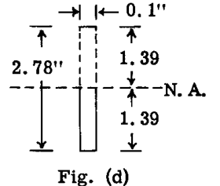

Fig. (d)

$$I = \frac{1}{12} bh^3 = \frac{1}{12} \times 0.1 \times 2.78^3 = 0.178$$

$$I_1/c_1 = 0.178 / 1.39 = .128$$

$$Q_1 = 1.39 \times 0.1 \times .695 = .0965$$

$$2Q_1 = .193$$

$$k_1 = 2Q_1 / I_1/c_1 = \frac{0.193}{0.128} = 1.5$$

Fig. C3.22 より、 $F_{tu} = 180000$ であり、これは $f_m$ に等しい。

曲線から $f_o = 156000$

したがって、

$$F_{b1} = f_m + f_o(k - 1) = 180000 + 156000(1.5 - 1) = 258000$$

$$M = (F_{b1} I_1/c_1) \frac{1}{2} = 258000 \times .128 \times 0.5 =
16550\text{ in. lb.}$$

係数 $1/2$ は、部分 (1) が Fig. (d) の梁断面の半分にすぎないという事実によるものである。

**部分 2** Fig. (e) は、梁断面の上部部分 (2) について作成された対称断面を示している。

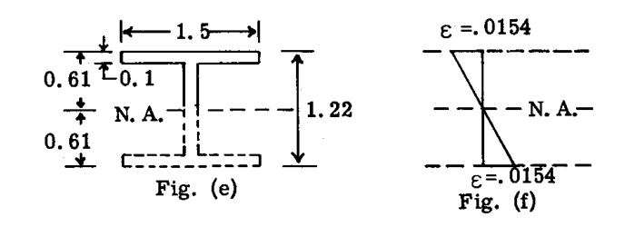

Fig. (e), Fig. (f)

単位ひずみ状態を Fig. (f) に示す。

$$I_2 = \frac{1}{12} \times 1.5 \times 1.22^3 - \frac{1}{12} \times 1.4
\times 1.02^3 = .104$$

$$I_2/c_2 = .104 / .61 = .1704$$

$$Q_2 = .61 \times .1 \times .305 + 1.4 \times 0.1 \times 0.56 = .097$$

$$2Q_2 = 0.194$$

$$k_2 = 0.194 / .1704 = 1.14$$

Fig. C3.22 の応力-ひずみ曲線より、単位ひずみ $.0154$ に対する応力は $172000$ であり、 $f_o = 129400$ である。

したがって、

$$F_{b2} = 172000 + 129400 (1.14 - 1) = 190100$$

$$M_2 = \frac{1}{2} (F_{b2} I_2/c_2) = 190100 \times .1704 \times 0.5 =
16200$$

全抵抗モーメント $= M_1 + M_2 = 16550 + 16200 = 32750\text{ in. lbs.}$

#### 解法 2

解法 (1) で行ったように各部分を対称断面にして結果を2倍で割る代わりに、梁断面全体の中立軸の周りに曲げたときの各部分の内部曲げ抵抗をそのまま求める。このとき、梁断面の各部分について、式 (3) は以下のようになる。

$$F_b = f_m + f_o (k - 1) \quad \text{--- } 3'$$

ここで、

$$k_1 = \frac{Q_1}{I_1/c_1} , \quad k_2 = \frac{Q_2}{I_2/c_2}$$

各部分の断面係数は、梁断面全体の中立軸を基準とする。Fig. (g) は下部部分 (1) を示している。

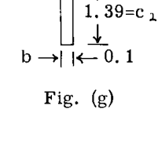

Fig. (g)

$$I_1 = \frac{1}{3} b c_1^3 = \frac{1}{3} \times .1 \times 1.39^3 = .0895$$

$$I_1/c_1 = .0895 / 1.39 = .0645$$

$$Q_1 = 1.39 \times .1 \times .695 = .0965$$

$$k_1 = Q_1 / (I_1/c_1) = .0965 / .0645 = 1.50$$

式 (3’) より、

$$F_b = 180000 + 156000(1.50 - 1) = 258000$$

$$M_1 = F_{b1} \times I_1/c_1 = 258000 \times .0645 = 16620$$

Fig. (h) は上部部分 (2) を示している。

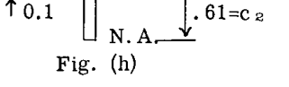

Fig. (h)

$$I_2 = \frac{1}{3} \times 1.5 \times .61^3 - \frac{1}{3} \times 1.4
\times .51^3 = .0514$$

$$I_2/c_2 = .0514 / .61 = .0842$$

$$Q_2 = 0.61 \times 0.1 \times .305 + 1.4 \times .1 \times .561 = .0971$$

$$k_2 = .0971 / .0842 = 1.15$$

解法 (1) で説明したように、 $\epsilon = .0154$ に対し、 $f_m = 172000$ および $f_o = 129400$ である。

$$F_{b2} = 172000 + 129400(1.15 - 1) = 191400$$

$$M_2 = 191400 \times .0842 = 16100$$

$$M_{total} = M_1 + M_2 = 16620 + 16100 = 32720\text{ in. lb.}$$

### 例題 4

Fig. C3.24 は非対称なI形梁断面を示している。材料は 7079-T6アルミ合金型鍛造材である。上部部分は曲げ圧縮状態にある。断面の突出した上部脚部の圧縮座屈応力は $65000\text{ psi}$ であると仮定する。（圧縮座屈強度を計算する理論と方法は別の章で説明する。）極限設計曲げモーメントは $16500\text{ in. lb.}$ である。安全余裕（M.S.）を求めよ。

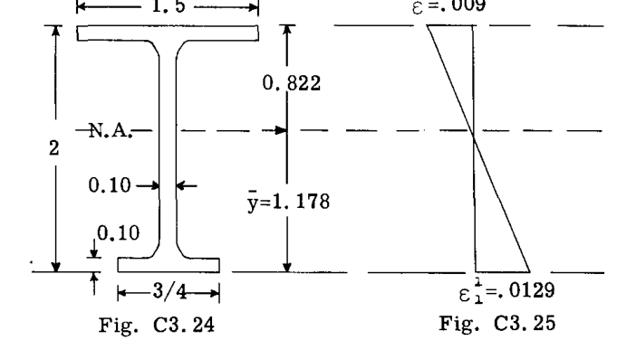

Fig. C3.24, Fig. C3.25

解法：

$$\bar{y} = \frac{2 \times 0.1 \times 1 + 1.4 \times 0.1 \times 1.95 + .65
\times 0.1 \times .05}{2 \times 0.1 + 1.4 \times 0.1 + .65 \times 0.1} =
1.178$$

許容される最大圧縮応力は $65000\text{ psi}$ である。Fig. C3.23 の応力-ひずみ曲線を用いることで、この応力に対して $0.009$ の単位ひずみを得る。断面下端における単位ひずみは、Fig. C3.25 に示すように $.009 \times (1.178 / 0.822) = .0129$ となる。Fig. C3.23 から、このひずみは $67500\text{ psi}$ の応力を発生させる。

上部部分: (Fig. 1 を参照)

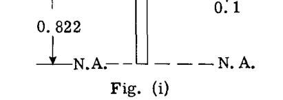

Fig. (i)

$$I_{NA} = \frac{1}{3} \times 1.5 \times .822^3 - \frac{1}{3} \times 1.4
\times 0.722^3 = .102$$

$$I/c = .102 / .822 = .124$$

$$Q = 0.822 \times 0.1 \times 0.411 + 1.4 \times 0.1 \times 0.772 = .1418$$

$$k = .1418 / .124 = 1.142$$

$$f_{max} = 65000$$

Fig. C3.23 より、 $f_o = 30000$

したがって、

$$f_b = 65000 + 30000 (1.142 - 1) = 69260$$

$$m_1 = f_b I/c = 69260 \times .124 = 8580\text{ in. lb.}$$

下部部分：

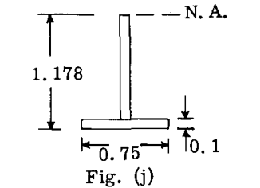

Fig. (j)

$$I_{NA} = \frac{1}{3} \times 0.75 \times 1.178^3 - \frac{1}{3} \times
0.65 \times 1.078^3$$

$$I_{NA} = .137, \quad I/c = .137 / 1.178 = .1164$$

$$k = .1425 / .1164 = 1.222$$

$$f_{max} = 67500$$

Fig. C3.23 より、 $f_o = 44500$

$$f_b = 67500 + 44500(1.222 - 1) = 77370\text{ psi}$$

$$m_2 = .1164 \times 77370 = 9000\text{ in. lb.}$$

許容される全内部抵抗モーメント $= m_1 + m_2$

または、

$$M_a = 8580 + 9000 = 17580\text{ in. lb.}$$

$$R_b = \frac{M}{M_a} = \frac{16500}{17580} = 0.94 \quad \text{(荷重比)}$$

$$\text{M.S.} = \frac{1}{R_b} - 1 = \frac{1}{0.94} - 1 = .06$$

## C3.8 複合曲げ、対称断面、主軸に平行でないモーメントベクトル

Fig. C3.26 は二重対称断面を示している。 $x$ 軸および $y$ 軸はしたがって主軸である。

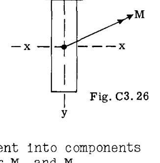

Fig. C3.26

以下に示す、かなり安全側の手順に従うことができる。

1. 与えられたモーメントを $x$ 軸および $y$ 軸周りの成分、すなわち $M_x$ および $M_y$ に分解する。
2. $M_x$ を用い、例題で示した手順に従って $R_{bx} = M_x / M_{ax}$ を求める。ここで $M_{ax}$ は、 $x$ 軸周りの曲げにおいて断面が発生する内部抵抗モーメントであり、 $M_x$ は設計曲げモーメントである。
3. $M_y$ を用いて、 $y$ 軸周りの曲げについて同様の手順を行い、 $R_{by} = M_y / M_{ay}$ を求める。

次に、複合曲げに対するモーメント比 $R_b$ は、

$$R_b = R_{bx} + R_{by}$$

となる。このとき、安全余裕は以下のようになる。

$$\text{M.S.} = \frac{1}{R_b} - 1$$

## C3.9 一つの対称軸を持つ断面、モーメントベクトルがどちらの軸にも平行でない場合

対称軸が主軸であるため、この場合の計算手順は二重対称の場合と同様である。

$$R_b = R_{bx} + R_{by}$$

$$\text{M.S.} = \frac{1}{R_b} - 1$$

## C3.10 対称軸を持たない非対称断面

Fig. C3.27 は、作用モーメントベクトル $M$ を受ける非対称断面を示している。

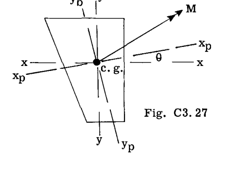

Fig. C3.27

この場合の計算手順は以下の通りである。

1. 次の公式により主軸の位置を決定する。

$$\tan 2\theta = \frac{2I_{xy}}{I_y - I_x}$$

ここで、 $x$ および $y$ は図心軸、 $I_x$ および $I_y$ はこれらの軸周りの慣性モーメント、 $I_{xy}$ は相乗慣性モーメントである。

2. 与えられたモーメント $M$ を成分 $M_{xp}$ および $M_{yp}$ に分解する。
3. 前述と同様の手順に従う。
4. 応力比 $R_b = R_{bxp} + R_{byp}$

$$\text{M.S.} = \frac{1}{R_b} - 1$$